```python
import numpy as np
import matplotlib.pyplot as plt
from sklearn.linear_model import LinearRegression, Ridge, LogisticRegression
from sklearn.datasets import load_diabetes, load_digits, fetch_openml
from sklearn.model_selection import train_test_split
from sklearn.metrics import mean_squared_error, accuracy_score, classification_report, log_loss
```

# Lineare Regression

## Daten und Vorbereitung

Datensatz zur Vorhersage von Blutzuckerwerten (Diabetes mellitus) laden:

```python
diabetes = load_diabetes()
diabetes.data.shape
```

```
(442, 10)
```

Beispiel: die ersten 10 Datenpunkte

```python
print(diabetes.feature_names)
print(np.round(diabetes.data[:10, :], 3))
print("Zielvariable:", diabetes.target[:10])
```

```
['age', 'sex', 'bmi', 'bp', 's1', 's2', 's3', 's4', 's5', 's6']
[[ 0.038  0.051  0.062  0.022 -0.044 -0.035 -0.043 -0.003  0.02  -0.018]
 [-0.002 -0.045 -0.051 -0.026 -0.008 -0.019  0.074 -0.039 -0.068 -0.092]
 [ 0.085  0.051  0.044 -0.006 -0.046 -0.034 -0.032 -0.003  0.003 -0.026]
 [-0.089 -0.045 -0.012 -0.037  0.012  0.025 -0.036  0.034  0.023 -0.009]
 [ 0.005 -0.045 -0.036  0.022  0.004  0.016  0.008 -0.003 -0.032 -0.047]
 [-0.093 -0.045 -0.041 -0.019 -0.069 -0.079  0.041 -0.076 -0.041 -0.096]
 [-0.045  0.051 -0.047 -0.016 -0.04  -0.025  0.001 -0.039 -0.063 -0.038]
 [ 0.064  0.051 -0.002  0.067  0.091  0.109  0.023  0.018 -0.036  0.003]
 [ 0.042  0.051  0.062 -0.04  -0.014  0.006 -0.029 -0.003 -0.015  0.011]
 [-0.071 -0.045  0.039 -0.033 -0.013 -0.035 -0.025 -0.003  0.068 -0.014]]
Zielvariable: [151.  75. 141. 206. 135.  97. 138.  63. 110. 310.]
```

Daten sind bereits standardisiert (mit $\mu = 0$ und $\sigma = \sqrt{1 / n}$).

```python
print(np.round(diabetes.data.mean(axis=0), 5))
print(diabetes.data.std(axis=0))
```

```
[-0.  0. -0. -0. -0.  0. -0. -0.  0.  0.]
[0.04756515 0.04756515 0.04756515 0.04756515 0.04756515 0.04756515
 0.04756515 0.04756515 0.04756515 0.04756515]
```

Aufteilung in Trainings- und Testdaten, wobei durch `random_state` die Replizierbarkeit sichergestellt wird (aber probieren Sie auch andere Werte für `random_state` aus!).

```python
X_train, X_test, y_train, y_test = train_test_split(
    diabetes.data, diabetes.target, test_size=0.5, random_state=666)
```

## Regression mit Scikit-Learn

Zur Kontrolle führen wir eine lineare Regression mit Scikit-Learn durch: unsere Ergebnisse sollten ähnlich sein (sowohl bzgl. der Vorhersagegüte als auch vergleichbare Parameterwerte).

```python
model = LinearRegression().fit(X_train, y_train)
model.score(X_test, y_test) # R2 = Anteil der Varianz
```

```
0.518443657341312
```

Intuitives Gütemaß für die Regressionsvorhersagen ist unser Loss: *mean squared error* (MSE). Zur besseren Interpretierbarkeit verwenden wir hier *root mean squared error* (rMSE), das die gleiche Skalierung wie die Zielvariable hat.

```python
y_pred = model.predict(X_test)
mean_squared_error(y_test, y_pred, squared=False)
```

```
54.33996933103096
```

Modellparameter:

```python
print(np.round(model.coef_, 1))       # w
print(np.round(model.intercept_, 1))  # b
```

```
[ -17.4 -173.6  688.   254.2 -503.2  155.5   28.6  146.3  635.     2.9]
151.5
```

Wir können auch die Korrelation zwischen den vorhergesagten Werten des Modells und dem Gold Standard visualisieren:

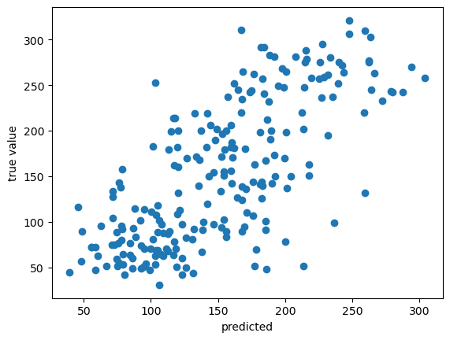

```python
plt.scatter(y_pred, y_test)
plt.xlabel("predicted")
plt.ylabel("true value");
```

Zum Vergleich berechnen wir rMSE auf den Trainingsdaten: gibt es Anzeichen für Überanpassung?

```python
mean_squared_error(y_train, model.predict(X_train), squared=False)
```

```
53.89188934788393
```

> **Aufgabe:** Probieren Sie alternativ *Ridge Regression* aus (`Ridge`), das die lineare Regression mit einer Regularisierung kombiniert. Wie verändern sich dabei die Lernergebnisse?

```python
ridge = Ridge(alpha=1.0).fit(X_train, y_train)
print(mean_squared_error(y_train, ridge.predict(X_train), squared=False))
print(np.round(ridge.coef_, 1))
print(np.round(ridge.intercept_, 1))
```

```
61.21449699318729
[  25.3  -24.2  242.4  132.3   14.8   -9.9 -102.3   92.7  180.9   71. ]
151.6
```

## Eigene Implementierung des Regressionsmodells

Wir implementieren unser Modell als Python-Klasse, um die Parameter $\mathbf{w}$ und $b$ zusammenzufassen und die wichtigsten Methoden bereitzustellen. Dabei können wir im wesentlichen die Formeln aus der Vorlesung abtippen und verwenden auch weitgehend die dort eingeführten Bezeichnungen.

Im Gegensatz zum SKLTagger ist hier nicht beabsichtigt, die API von Scikit-Learn anzubieten. Auch auf eine Fehlerbehandlung verzichten wir der Übersichtlichkeit zuliebe.

```python
class Linear:
    def __init__(self, d):
        self.dim = d
        self.w = np.zeros(d)
        self.b = 0.0

    def f(self, X):
        return np.dot(X, self.w) + self.b

    def predict(self, X):
        return self.f(X)

    def loss(self, X, y):
        z = self.f(X)
        return np.square(y - z).mean()

    def score(self, X, y):
        return np.sqrt(self.loss(X, y))

    def grad(self, X, y):
        z = self.f(X)
        n = y.shape[0]
        grad_b = -2.0 * np.sum(y - z) / n
        grad_w = -2.0 * np.dot(y - z, X) / n
        return (grad_w, grad_b)
```

Zum Testen fügen wir einfach die Parameter des Scikit-Learn-Modells ein:

```python
linear = Linear(10)
linear.w = model.coef_
linear.b = model.intercept_
```

Damit können wir Vorhersagen für die Testdaten berechnen und mit dem Scikit-Learn-Modell sowie den tatsächlichen Werten vergleichen:

```python
tmp = np.vstack([
    linear.predict(X_test),
    model.predict(X_test),
    y_test
])
print(np.round(tmp[:, 0:10], 1))
```

```
[[287.6 103.  227.1  78.1 108.9 122.9  88.5 154.4 217.9  74.3]
 [287.6 103.  227.1  78.1 108.9 122.9  88.5 154.4 217.9  74.3]
 [242.   53.  236.   80.   88.   60.   84.  151.  151.   59. ]]
```

Auch unsere Loss-Funktion $L(\mathbf{w}, b; T)$ sollte mit dem oben berechneten rMSE übereinstimmen.

```python
np.sqrt(linear.loss(X_test, y_test))
```

```
54.33996933103096
```

Berechnung des Gradienten bzgl. der Testdaten:

```python
[np.round(x, 3) for x in linear.grad(X_test, y_test)]
```

```
[array([-0.321,  0.123,  0.633, -0.414, -0.68 , -0.772,  0.169, -0.538,
        -0.312, -0.556]),
 -2.363]
```

Warum ist der folgende Gradient = 0?

```python
[np.round(x, 3) for x in linear.grad(X_train, y_train)]
```

```
[array([ 0., -0., -0., -0., -0., -0.,  0., -0., -0., -0.]), 0.0]
```

## Der Gradient Descent-Algorithmus

Wir beginnen mit einer naiven Implementierung des Gradient Descent-Verfahrens. Der Algorithmus ist eigentlich unabhängig vom zugrundeliegenden Vorhersagemodell und würde im Prinzip mit jeder Klasse funktionieren, die dieselbe Schnittstelle wie unsere `Linear`-Klasse bereitstellt. Der Einfachheit halber sind die Parameter $\mathbf{w}, b$ fest im Programm verdrahtet, so dass nur Modelle mit diesen Parametern verwendet werden können. Das umfasst aber immerhin auch die logistische Regression.

> **Aufgabe:** Implementieren Sie die einfachste Variante eines Gradient Descent-Verfahrens. Ein Vorschlag für die Signatur der zu schreibenden Funktion ist unten vorgegeben. Sie sollte folgendermaßen ablaufen:
> - `model` muss ein neu initialisiertes Objekt einer geeigneten Klasse sein (nicht `linear` von oben!)
> - in jedem Schritt wird zunächst der Loss auf den Trainingsdaten berechnet und ausgegeben (sowie optional auch ein Evaluationsergebnis auf den Testdaten `validation_data=(X_test, y_test)`)
> - dann wird der Gradient berechnet, mit der Lernrate $\lambda$ mutlipliziert und damit die Parameterwerte von `model` aktualisiert
> - das Verfahren läuft immer für die übergebene Anzahl von `max_steps`, so dass Sie keine Konvergenzprüfung vornehmen müssen

```python
def gradient_descent(model, X, y, learning_rate=.1, max_steps=1000, validation_data=None):
    update = 0
    for step in range(max_steps):
        if step >= update:
            L = model.loss(X, y)
            msg = f"{step:6d}.  loss = {L:<12.2f}"
            if validation_data is not None:
                L2 = model.score(validation_data[0], validation_data[1])
                msg += f"  test score = {L2:<8.2f}"
            print(msg)
            update += 1 + update // 5 # Ausgaben in immer größeren Abständen

        nabla = model.grad(X, y)
        model.w -= nabla[0] * learning_rate
        model.b -= nabla[1] * learning_rate
```

Zum Testen Ihres Verfahrens trainieren Sie ein lineares Modell auf dem Trainingsdatensatz und vergleichen es mit den oben gezeigten Ergebnissen.

```python
linear_gd = Linear(10) # immer neu initialisieren!
gradient_descent(linear_gd, X_train, y_train, validation_data=(X_test, y_test))
```

```
     0.  loss = 28531.90      test score = 172.10
     1.  loss = 20316.06      test score = 145.82
     2.  loss = 15055.82      test score = 126.08
     3.  loss = 11687.12      test score = 111.53
     4.  loss = 9528.99       test score = 101.04
     5.  loss = 8145.61       test score = 93.65
     7.  loss = 6687.86       test score = 85.03
     9.  loss = 6083.62       test score = 81.07
    11.  loss = 5829.00       test score = 79.26
    14.  loss = 5686.83       test score = 78.15
    17.  loss = 5636.42       test score = 77.71
    21.  loss = 5603.22       test score = 77.40
    26.  loss = 5572.42       test score = 77.13
    32.  loss = 5537.94       test score = 76.84
    39.  loss = 5498.71       test score = 76.52
    47.  loss = 5454.92       test score = 76.17
    57.  loss = 5401.67       test score = 75.73
    69.  loss = 5339.88       test score = 75.22
    83.  loss = 5270.59       test score = 74.64
   100.  loss = 5190.29       test score = 73.96
   121.  loss = 5096.58       test score = 73.16
   146.  loss = 4992.36       test score = 72.25
   176.  loss = 4876.97       test score = 71.22
   212.  loss = 4751.04       test score = 70.08
   255.  loss = 4616.47       test score = 68.84
   307.  loss = 4473.62       test score = 67.48
   369.  loss = 4327.20       test score = 66.05
   443.  loss = 4180.12       test score = 64.58
   532.  loss = 4034.58       test score = 63.08
   639.  loss = 3893.76       test score = 61.59
   767.  loss = 3760.70       test score = 60.17
   921.  loss = 3635.98       test score = 58.84
```

Falls das Verfahren in der vorgegebenen Anzahl Schritte konvergiert, sollten die Parameterwerte ungefähr mit dem Scikit-Learn-Modell übereinstimmen.

```python
print(np.round(linear_gd.w, 1))
print(np.round(linear_gd.b, 1))
```

```
[  37.7  -15.   273.7  157.    30.     5.  -125.1  119.2  209.8   94.6]
151.7
```

> **Aufgabe:** Verbessern Sie Ihre Implementierung von Gradient Descent, indem Sie etwa
> - den Algorithmus beenden, wenn der Loss auf den Trainingsdaten konvergiert
> - automatisch die Lernrate anpassen (z.B. nach einer bestimmten Zahl Schritte halbieren)
> - GD mit Momentum implementieren
> - eine optionale Regularisierung ermöglichen (am besten mit $L_2$-Penalty, so dass $\nabla C(\mathbf{w})$ leicht zu berechnen ist)

```python
def gradient_descent(model, X, y, learning_rate=.1, momentum=.5, alpha=0, tol=1e-4, max_steps=10000, validation_data=None):
    update = 0
    gradient = [np.zeros(model.dim), 0.0]
    prev_L = 0.0
    for step in range(max_steps):
        if step >= update:
            L = model.loss(X, y)
            msg = f"{step:6d}.  loss = {L:<12.2f}"
            if validation_data is not None:
                L2 = model.score(validation_data[0], validation_data[1])
                msg += f"  test score = {L2:<8.2f}"
            print(msg)
            update += 1 + update // 5 # Ausgaben in immer größeren Abständen

            # check convergence only when printing updates
            if prev_L > 0.0:
                diff = abs(L - prev_L) / abs(L)
                if diff < tol:
                    return True
            prev_L = L

        nabla = model.grad(X, y)
        gradient[0] = momentum * gradient[0] - (nabla[0] + 2.0 * alpha * model.w) * learning_rate
        gradient[1] = momentum * gradient[1] - nabla[1] * learning_rate
        model.w += gradient[0]
        model.b += gradient[1]

    return False # model failed to converge
```

Ridge Regression verwendet den gesamten (nicht *mittleren*) quadratischen Fehler $\sum_i (y_i - \hat{y}_i)^2$ als Zielfunktion und addiert den Regularisierungsterm $\alpha \cdot \sum_j w_j^2$. Da unsere Implementierung den mittleren quadratischen Fehler benutzt, müssen wir als Regularisierungsfaktor $\alpha = \frac{1}{n}$ ansetzen, um die gleichen Ergebnisse zu erhalten wie Ridge Regression mit $\alpha = 1$.

```python
linear_gd = Linear(10)
gradient_descent(linear_gd, X_train, y_train, alpha=1.0/len(y_train), validation_data=(X_test, y_test))
```

```
     0.  loss = 28531.90      test score = 172.10
     1.  loss = 20316.06      test score = 145.82
     2.  loss = 12361.85      test score = 114.60
     3.  loss = 7781.42       test score = 91.60
     4.  loss = 6033.07       test score = 80.73
     5.  loss = 5680.22       test score = 78.01
     7.  loss = 5765.60       test score = 78.19
     9.  loss = 5688.46       test score = 77.74
    11.  loss = 5614.33       test score = 77.37
    14.  loss = 5573.48       test score = 77.14
    17.  loss = 5539.71       test score = 76.87
    21.  loss = 5495.87       test score = 76.50
    26.  loss = 5443.26       test score = 76.07
    32.  loss = 5382.79       test score = 75.57
    39.  loss = 5315.72       test score = 75.02
    47.  loss = 5243.37       test score = 74.41
    57.  loss = 5158.93       test score = 73.69
    69.  loss = 5065.63       test score = 72.89
    83.  loss = 4966.72       test score = 72.02
   100.  loss = 4859.32       test score = 71.07
   121.  loss = 4743.18       test score = 70.01
   146.  loss = 4624.90       test score = 68.92
   176.  loss = 4506.23       test score = 67.80
   212.  loss = 4390.17       test score = 66.69
   255.  loss = 4280.10       test score = 65.61
   307.  loss = 4177.38       test score = 64.60
   369.  loss = 4085.52       test score = 63.68
   443.  loss = 4005.54       test score = 62.89
   532.  loss = 3937.51       test score = 62.22
   639.  loss = 3881.69       test score = 61.69
   767.  loss = 3837.88       test score = 61.28
   921.  loss = 3804.87       test score = 60.98
  1106.  loss = 3781.41       test score = 60.78
  1328.  loss = 3765.84       test score = 60.65
  1594.  loss = 3756.36       test score = 60.57
  1913.  loss = 3751.17       test score = 60.53
  2296.  loss = 3748.67       test score = 60.51
  2756.  loss = 3747.66       test score = 60.50
  3308.  loss = 3747.32       test score = 60.50
```

```
True
```

```python
print(np.round(linear_gd.w, 1))
print(np.round(linear_gd.b, 1))
```

```
[  25.3  -24.2  242.3  132.3   14.8   -9.9 -102.3   92.7  180.9   71. ]
151.6
```

# Logistische Regression

## Daten und Vorbereitung

Wir arbeiten hier einen kleinen Beispieldatensatz handschriftlicher Ziffern, der in Scikit-Learn enthalten ist und nur eine Auflösung von $8\times 8$ Pixeln verwendet. Zur Vereinfachung wollen wir nur die **Ziffern 0** und **1** unterscheiden, so dass wir die Aufgabe als binäres Klassifikationsproblem behandeln und die logistische Regression direkt anwenden können.

[figure not shown]

Der Datensatz enthält jeweils 180 Beispiele für die Ziffern 0 und 1. Sie sind als flache Merkmalsvektoren $\mathbf{x}_i \in \mathbb{R}^64$ und alternativ auch als $8\times 8$-Matrizen bereitgestellt.

```python
digits = load_digits(n_class=2)
print(digits.data.shape)
print(digits.images.shape)
```

```
(360, 64)
(360, 8, 8)
```

Visualisierung und zugehörige Zielvariablen:

```
[0 1 0 1 0 1 0 0]
```

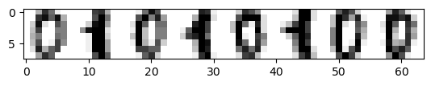

```python
plt.imshow(np.hstack(digits.images[0:8]), cmap="binary")
print(digits.target[0:8])
```

Die Pixelwerte sind als Graustufen zwischen 0 und 16 angegeben. Wir skalieren sie unten auf den Wertebereich $[0, 1]$.

Aufteilung in Trainings- und Testdaten. Wir verwenden Variablennamen `XX_*` und `yy_*` um die Daten für die lineare Regression aus dem ersten Teil der Übung nicht zu überschreiben.

```python
XX_train, XX_test, yy_train, yy_test = train_test_split(
    digits.data / 16.0, digits.target, test_size=0.5, random_state=666)
```

## Logistische Regression mit Scikit-Learn

Zur Kontrolle trainieren wir wiederum ein Scikit-Learn-Modell. Da es im Gegensatz zur linearen Regression keine exakte Lösung gibt, die direkt berechnet werden kann, müssen wir damit rechnen, dass das iterative Optimierungsverfahren von Scikit-Learn zu leicht anderen Ergebnissen kommt als unsere Implementierung.

```python
model = LogisticRegression(penalty='l2').fit(XX_train, yy_train)
model.score(XX_test, yy_test)
```

```
1.0
```

Die Aufgabenstellung ist offensichtlich so einfach (auch aufgrund der extrem ähnlichen Schreibung der Ziffern), dass auch mit diesem kleinen Trainingsdatensatz eine perfekte Klassifikation gelernt werden kann.

```python
yy_pred = model.predict(XX_test)
print(classification_report(yy_test, yy_pred))
```

```
              precision    recall  f1-score   support

           0       1.00      1.00      1.00        89
           1       1.00      1.00      1.00        91

    accuracy                           1.00       180
   macro avg       1.00      1.00      1.00       180
weighted avg       1.00      1.00      1.00       180
```

Idealerweise sollte unsere Implementierung der logistischen Regression ähnliche Merkmalsgewichte lernen. Wir können diese sogar visualisieren und sehen dabei eine intuitiv gut nachvollziehbare Verteilung.

```
[[ 0.    0.   -0.06 -0.52 -0.29  0.58  0.23  0.  ]
 [ 0.   -0.01 -0.56 -0.23  0.14 -0.19  0.17  0.  ]
 [ 0.02  0.15 -0.41  0.82  1.09 -0.38 -0.11  0.  ]
 [ 0.01 -0.09 -0.27  0.85  1.06 -0.21 -0.49  0.  ]
 [ 0.   -0.47 -0.62  0.87  1.08 -0.27 -0.55  0.  ]
 [ 0.   -0.23 -0.81  0.56  0.8  -0.5  -0.44  0.  ]
 [ 0.   -0.04 -0.7  -0.17 -0.04 -0.48  0.08  0.06]
 [ 0.    0.   -0.07 -0.54 -0.24  0.42  0.41  0.13]]
```

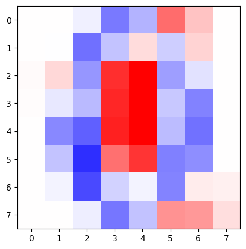

```python
weights = model.coef_[0].reshape((8, 8))
plt.imshow(weights, cmap="bwr", vmin=-1, vmax=1)
print(np.round(weights, 2))
```

## Eigene Implementierung der logistischen Regression

> **Aufgabe:** Implementieren Sie den Klassifikationsalgorithmus der (binären) logistischen Regression als Klasse `Logistic`.
> - Stellen Sie dabei dieselben Methoden zur Verfügung wie in der Klasse `Linear` für lineare Regression.
> - Beachten Sie, dass die Zielkategorien wie üblich als Werte 0 (negativ) und 1 (positiv) angegeben werden. Übersetzen Sie diese intern in $-1$ und $+1$, um die Formeln aus der Vorlesung anwenden zu können.
> - Es könnte nützlich sein, zusätzlich eine Methode `predict_proba()` zu implementieren, die die Wahrscheinlichkeit für die positive Klasse zurückliefert.

```python
class Logistic:
    def __init__(self, d):
        self.dim = d
        self.w = np.zeros(d)
        self.b = 0.0

    def f(self, X):
        return np.dot(X, self.w) + self.b

    def predict(self, X):
        return np.where(self.f(X) >= 0, 1, 0)

    def predict_proba(self, X):
        z = self.f(X)
        return 1.0 / (1.0 + np.exp(-z))

    def loss(self, X, y):
        z = self.f(X)
        y = np.where(y, 1.0, -1.0)
        return np.log(1.0 + np.exp(-y * z)).mean()

    def score(self, X, y):
        return 100 * np.mean(self.predict(X) == y)

    def grad(self, X, y):
        z = self.f(X)
        y = np.where(y, 1.0, -1.0)
        n = y.shape[0]
        outer_deriv = 1.0 / (1.0 + np.exp(y * z))
        grad_b = -np.dot(y, outer_deriv) / n
        grad_w = -np.dot(outer_deriv * y, X) / n
        return (grad_w, grad_b)
```

> **Aufgabe:** Testen Sie Ihre Implementierung, indem Sie wie im ersten Teil der Übung die vom Scikit-Learn-Modell gelernten Parameter in Ihr Objekt einfügen und es dann auf den Testdatensatz anwenden. Berechnen Sie auch den Gradienten für die Trainingsdaten.

```python
logistic = Logistic(64)
logistic.w = model.coef_[0]
logistic.b = model.intercept_

print(logistic.score(XX_test, yy_test))
print(np.round(logistic.predict_proba(XX_test), 2))

[np.round(x, 3) for x in logistic.grad(XX_train, yy_train)]
```

```
100.0
[0.99 0.01 0.99 0.01 0.01 0.04 0.01 0.01 0.98 0.01 0.01 0.99 0.99 0.03
 0.06 1.   0.   0.01 0.98 1.   0.99 0.01 1.   0.99 0.95 0.03 0.01 0.9
 0.01 0.   0.01 0.03 0.96 0.02 0.03 1.   0.99 0.04 1.   1.   0.01 0.05
 0.15 0.96 0.94 1.   0.98 0.99 0.02 0.99 0.99 0.15 0.01 1.   0.02 0.01
 1.   1.   0.01 0.09 0.   0.01 0.01 0.02 1.   0.03 0.97 0.91 0.94 0.96
 0.   0.97 0.84 0.02 0.01 0.99 0.05 0.02 0.99 0.02 0.99 0.98 0.01 1.
 0.01 0.98 0.99 0.03 0.99 0.99 1.   0.99 0.98 1.   0.96 1.   0.01 0.06
 0.95 0.02 1.   0.99 1.   0.02 0.99 0.01 0.99 0.99 0.93 0.02 0.96 0.99
 0.97 0.01 0.95 0.07 1.   0.02 0.01 1.   0.02 0.99 1.   0.04 0.95 0.01
 0.01 0.01 1.   0.99 0.99 0.01 0.02 0.99 0.01 1.   0.99 0.   0.   0.01
 1.   0.97 0.02 0.99 0.   0.01 1.   0.98 0.99 0.99 0.01 0.02 0.01 0.99
 0.   0.95 1.   0.04 0.98 0.01 0.   1.   0.02 0.02 0.   0.02 0.29 1.
 0.96 0.02 0.98 0.01 0.89 0.01 0.01 0.01 0.91 0.02 0.03 0.99]
```

```
[array([-0.   , -0.   ,  0.   ,  0.003,  0.002, -0.003, -0.001, -0.   ,
        -0.   ,  0.   ,  0.003,  0.001, -0.001,  0.001, -0.001, -0.   ,
        -0.   , -0.001,  0.002, -0.005, -0.006,  0.002,  0.001, -0.   ,
        -0.   ,  0.   ,  0.001, -0.005, -0.006,  0.001,  0.003, -0.   ,
        -0.   ,  0.003,  0.003, -0.005, -0.006,  0.001,  0.003, -0.   ,
        -0.   ,  0.001,  0.005, -0.003, -0.004,  0.003,  0.002, -0.   ,
        -0.   ,  0.   ,  0.004,  0.001,  0.   ,  0.003, -0.   , -0.   ,
        -0.   , -0.   ,  0.   ,  0.003,  0.001, -0.002, -0.002, -0.001]),
 -0.0]
```

## Gradient Descent für die logistische Regression

Ihre Implementierung des Gradient Descent-Algorithmus aus dem ersten Teil sollte auch mit der Klasse `Logistic` funktionieren.

> **Aufgabe:** Trainieren Sie Ihr Modell mit der Funktion `gradient_descent()` und evaluieren Sie es auf den Testdaten.
> - Sind die Ergebnisse ähnlich gut wie mit Scikit-Learn?
> - Warum konvergiert das Modell ohne Regularisierung nicht, auch wenn es auf den Testdaten schon eine perfekte Klassifikation erreicht?

```python
logistic = Logistic(64)
gradient_descent(logistic, XX_train, yy_train, validation_data=(XX_test, yy_test))
```

```
     0.  loss = 0.69          test score = 50.56
     1.  loss = 0.65          test score = 100.00
     2.  loss = 0.59          test score = 100.00
     3.  loss = 0.53          test score = 100.00
     4.  loss = 0.48          test score = 100.00
     5.  loss = 0.43          test score = 100.00
     7.  loss = 0.36          test score = 100.00
     9.  loss = 0.30          test score = 100.00
    11.  loss = 0.26          test score = 100.00
    14.  loss = 0.22          test score = 100.00
    17.  loss = 0.19          test score = 100.00
    21.  loss = 0.16          test score = 100.00
    26.  loss = 0.14          test score = 100.00
    32.  loss = 0.12          test score = 100.00
    39.  loss = 0.10          test score = 100.00
    47.  loss = 0.09          test score = 100.00
    57.  loss = 0.07          test score = 100.00
    69.  loss = 0.06          test score = 100.00
    83.  loss = 0.06          test score = 100.00
   100.  loss = 0.05          test score = 100.00
   121.  loss = 0.04          test score = 100.00
   146.  loss = 0.04          test score = 100.00
   176.  loss = 0.03          test score = 100.00
   212.  loss = 0.03          test score = 100.00
   255.  loss = 0.02          test score = 100.00
   307.  loss = 0.02          test score = 100.00
   369.  loss = 0.02          test score = 100.00
   443.  loss = 0.01          test score = 100.00
   532.  loss = 0.01          test score = 100.00
   639.  loss = 0.01          test score = 100.00
   767.  loss = 0.01          test score = 100.00
   921.  loss = 0.01          test score = 100.00
  1106.  loss = 0.01          test score = 100.00
  1328.  loss = 0.01          test score = 100.00
  1594.  loss = 0.00          test score = 100.00
  1913.  loss = 0.00          test score = 100.00
  2296.  loss = 0.00          test score = 100.00
  2756.  loss = 0.00          test score = 100.00
  3308.  loss = 0.00          test score = 100.00
  3970.  loss = 0.00          test score = 100.00
  4765.  loss = 0.00          test score = 100.00
  5719.  loss = 0.00          test score = 100.00
  6863.  loss = 0.00          test score = 100.00
  8236.  loss = 0.00          test score = 100.00
  9884.  loss = 0.00          test score = 100.00
```

```
False
```

```python
print(classification_report(yy_test, logistic.predict(XX_test)))
```

```
              precision    recall  f1-score   support

           0       1.00      1.00      1.00        89
           1       1.00      1.00      1.00        91

    accuracy                           1.00       180
   macro avg       1.00      1.00      1.00       180
weighted avg       1.00      1.00      1.00       180
```

> **Aufgabe:** Wenn Sie mit den Lernergebnissen zufrieden sind, können Sie die gelernten Parameter jetzt auch visualisieren.

```
[[ 0.    0.01 -0.07 -1.   -0.5   1.58  0.65  0.  ]
 [ 0.    0.07 -0.86 -0.32  0.62 -0.17  0.5   0.  ]
 [ 0.09  0.85 -0.47  2.01  2.59 -0.73 -0.11  0.  ]
 [ 0.04  0.2  -0.32  1.88  2.24 -0.37 -0.95  0.  ]
 [ 0.   -1.   -1.51  2.04  2.27 -0.52 -1.05  0.  ]
 [ 0.   -0.45 -1.82  1.05  1.41 -1.02 -0.83  0.  ]
 [ 0.   -0.09 -1.44 -0.48 -0.29 -0.91  0.32  0.13]
 [ 0.    0.01 -0.08 -0.97 -0.32  1.18  0.99  0.28]]
```

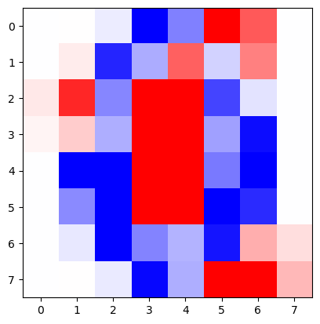

```python
weights = logistic.w.reshape((8, 8))
plt.imshow(weights, cmap="bwr", vmin=-1, vmax=1)
print(np.round(weights, 2))
```

## Freiwillige Zusatzaufgaben

Bearbeiten Sie eine der folgenden Zusatzaufgaben (oder beide).

> **Aufgabe:** Implementieren Sie *Stochastic Gradient Descent*.
> - Ergänzen Sie dazu Ihre Funktion `gradient_descent()` um eine innere Schleife, die für jede Epoche den Trainingsdatensatz in eine wählbare Anzahl von Mini-Batches aufteilt.
> - Der Parameter `max_steps` gibt nun die maximale Anzahl von Epochen vor. Bildschirmausgaben und Konvergenzprüfung sollten nur am Ende jeder vollständigen Epoche erfolgen.
> - Achten Sie darauf, die Trainingsdaten zu Beginn jeder Epoche zufällig umzusortieren (ggf. durch Parameter wählbar).
> - Trainieren Sie das Modell wie oben und vergleichen Sie die gefundenen Merkmalsgewichte.

Für das SGD-Verfahren modifizieren wir unsere Funktion `gradient_descent()`. Große Teile des Programmcodes können wir dabei unverändert übernehmen. Lediglich ein Parameter `batches` für die Anzahl Mini-Batches pro Epoche kommt hinzu.

```python
from sklearn.utils import shuffle
def sgd(model, X, y, learning_rate=.1, momentum=.5, alpha=0, tol=1e-4, batches=10,
        max_epochs=10000, validation_data=None):
    update = 0
    gradient = [np.zeros(model.dim), 0.0]
    prev_L = 0.0
    for step in range(max_epochs):
        # Konvergenzprüfung für jede Epoche durchführen
        L = model.loss(X, y)
        if prev_L > 0.0:
            diff = abs(L - prev_L) / abs(L)
            if diff < tol:
                return True
        prev_L = L

        if step >= update:
            msg = f"{step:6d}.  loss = {L:<12.2f}"
            if validation_data is not None:
                L2 = model.score(validation_data[0], validation_data[1])
                msg += f"  test score = {L2:<8.2f}"
            print(msg)
            update += 1 + update // 5 # Ausgaben in immer größeren Abständen

        X1, y1 = shuffle(X, y)      # zufällig umsortieren (aber X und y konsistent!)
        for batch in range(batches):
            X2 = X1[batch::batches] # Mini-Batches können am einfachsten mit einem
            y2 = y1[batch::batches] # round-robin-Schema erzeugt werden

            nabla = model.grad(X2, y2)
            gradient[0] = momentum * gradient[0] - (nabla[0] + 2.0 * alpha * model.w) * learning_rate
            gradient[1] = momentum * gradient[1] - nabla[1] * learning_rate
            model.w += gradient[0]
            model.b += gradient[1]

    return False # model failed to converge
```

Vergleich mit dem Training per `logistic_regression` zeigt, dass der Loss deutlich schneller sinkt. Ohne Regularisierung läuft das Training zwar immer noch recht lange, konvergiert aber bei einem etwas höher gewähltem Toleranzwert innerhalb von 1000 Epochen.

```python
logistic_sgd = Logistic(64)
sgd(logistic_sgd, XX_train, yy_train, tol=1e-3, validation_data=(XX_test, yy_test))
```

```
     0.  loss = 0.69          test score = 50.56
     1.  loss = 0.28          test score = 100.00
     2.  loss = 0.17          test score = 100.00
     3.  loss = 0.12          test score = 100.00
     4.  loss = 0.10          test score = 100.00
     5.  loss = 0.08          test score = 100.00
     7.  loss = 0.06          test score = 100.00
     9.  loss = 0.05          test score = 100.00
    11.  loss = 0.04          test score = 100.00
    14.  loss = 0.04          test score = 100.00
    17.  loss = 0.03          test score = 100.00
    21.  loss = 0.03          test score = 100.00
    26.  loss = 0.02          test score = 100.00
    32.  loss = 0.02          test score = 100.00
    39.  loss = 0.02          test score = 100.00
    47.  loss = 0.01          test score = 100.00
    57.  loss = 0.01          test score = 100.00
    69.  loss = 0.01          test score = 100.00
    83.  loss = 0.01          test score = 100.00
   100.  loss = 0.01          test score = 100.00
   121.  loss = 0.01          test score = 100.00
   146.  loss = 0.01          test score = 100.00
   176.  loss = 0.00          test score = 100.00
   212.  loss = 0.00          test score = 100.00
   255.  loss = 0.00          test score = 100.00
   307.  loss = 0.00          test score = 100.00
   369.  loss = 0.00          test score = 100.00
   443.  loss = 0.00          test score = 100.00
   532.  loss = 0.00          test score = 100.00
   639.  loss = 0.00          test score = 100.00
   767.  loss = 0.00          test score = 100.00
```

```
True
```

> **Aufgabe:** Testen Sie Ihr Modell mit dem schwierigeren MNIST-Datensatz.
> - Laden Sie die MNIST-Daten und reduzieren Sie sie auf die Ziffern 0 und 1.
> - Trainieren Sie logistische Regression mit Scikit-Learn und Ihrer eigenen Implementierung.
> - Vergleichen Sie die Evaluationsergebnisse. Wie schnell konvergiert Ihr Lernverfahren?
> - Visualisieren Sie die gelernten Merkmalsgewichte.
> - Bei dieser Aufgabe könnte sich Stochastic Gradient Descent als nützlich erweisen.
> - Versuchen Sie auch eine schwierigere Aufgabenstellung, z.B. die Ziffern 0 und 6 (oder 8 und 9)

```python
mnist = fetch_openml("mnist_784", version=1, as_frame=False)
```

Wir wandeln die kategorialen Label in Integer-Werte um und selektieren dann Ziffern $\leq 1$ (also 0 und 1).

```python
mnist.target = mnist.target.astype('int')
idx = mnist.target <= 1
MX = mnist.data[idx]
My = mnist.target[idx]
```

Zur Kontrolle: Visualisierung der ersten 8 Datenpunkte und Vergleich mit Labeln.

```
[0 1 1 1 1 0 1 1]
```

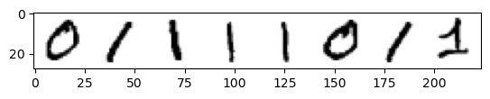

```python
tmp = MX.reshape(-1, 28, 28)
plt.imshow(np.hstack(tmp[0:8]), cmap="binary")
print(My[0:8])
```

Aufteilung in Trainings- und Testdaten wie gehabt.

```python
MX_train, MX_test, My_train, My_test = train_test_split(
    MX / 255.0, My, test_size=0.5, random_state=666)
```

Logistische Regression mit Scikit-Learn:

```python
model = LogisticRegression(penalty='l2', C=1)
model.fit(MX_train, My_train)
model.score(MX_test, My_test)
```

```
0.9990527740189445
```

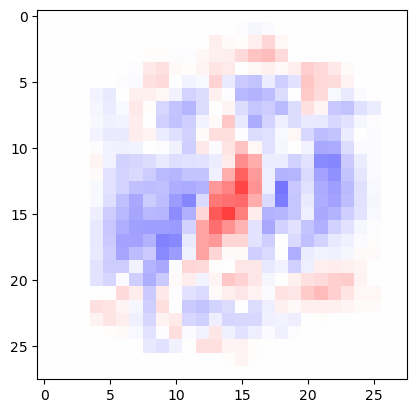

```python
weights = model.coef_[0].reshape(28, 28)
plt.imshow(weights, cmap="bwr", vmin=-1, vmax=1);
```

Unsere Implementierung der logistischen Regression ist nun deutlich langsamer. Ohne geeignete Regularisierung und eine hinreichend hohe Toleranz konvergiert die Optimierung auch nach 10.000 Schritten noch nicht.

```python
Mlogistic = Logistic(784)
gradient_descent(Mlogistic, MX_train, My_train, alpha=.001, tol=1e-2,
                 validation_data=(MX_test, My_test))
```

```
     0.  loss = 0.69          test score = 53.82
     1.  loss = 0.44          test score = 98.92
     2.  loss = 0.26          test score = 99.43
     3.  loss = 0.16          test score = 99.62
     4.  loss = 0.12          test score = 99.63
     5.  loss = 0.09          test score = 99.61
     7.  loss = 0.07          test score = 99.61
     9.  loss = 0.06          test score = 99.65
    11.  loss = 0.05          test score = 99.69
    14.  loss = 0.04          test score = 99.69
    17.  loss = 0.04          test score = 99.70
    21.  loss = 0.03          test score = 99.70
    26.  loss = 0.03          test score = 99.70
    32.  loss = 0.03          test score = 99.70
    39.  loss = 0.02          test score = 99.72
    47.  loss = 0.02          test score = 99.73
    57.  loss = 0.02          test score = 99.73
    69.  loss = 0.02          test score = 99.73
    83.  loss = 0.02          test score = 99.73
   100.  loss = 0.01          test score = 99.74
   121.  loss = 0.01          test score = 99.77
   146.  loss = 0.01          test score = 99.77
   176.  loss = 0.01          test score = 99.77
   212.  loss = 0.01          test score = 99.78
   255.  loss = 0.01          test score = 99.78
   307.  loss = 0.01          test score = 99.82
   369.  loss = 0.01          test score = 99.82
   443.  loss = 0.01          test score = 99.81
   532.  loss = 0.01          test score = 99.81
   639.  loss = 0.01          test score = 99.81
   767.  loss = 0.01          test score = 99.81
   921.  loss = 0.01          test score = 99.81
  1106.  loss = 0.01          test score = 99.82
  1328.  loss = 0.01          test score = 99.82
  1594.  loss = 0.00          test score = 99.84
  1913.  loss = 0.00          test score = 99.84
  2296.  loss = 0.00          test score = 99.84
  2756.  loss = 0.00          test score = 99.84
  3308.  loss = 0.00          test score = 99.84
  3970.  loss = 0.00          test score = 99.84
  4765.  loss = 0.00          test score = 99.84
  5719.  loss = 0.00          test score = 99.84
```

```
True
```

```python
My_pred = Mlogistic.predict(MX_test)
print(classification_report(My_test, My_pred))
```

```
              precision    recall  f1-score   support

           0       1.00      1.00      1.00      3413
           1       1.00      1.00      1.00      3977

    accuracy                           1.00      7390
   macro avg       1.00      1.00      1.00      7390
weighted avg       1.00      1.00      1.00      7390
```

Die Visualisierung der Merkmalsgewichte stimmt weitgehend mit dem Scikit-Learn-Modell überein, zeigt aber die deutlich stärkere Regularisierung unseres Verfahren.

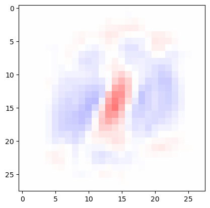

```python
weights = Mlogistic.w.reshape(28, 28)
plt.imshow(weights, cmap="bwr", vmin=-1, vmax=1);
```

Auch hier trainieren wir das Modell bei gleichen Einstellungen mit dem SGD-Algorithmus. Trotz engerer Toleranz konvergiert die Optimierung erheblich schneller (auch wenn jede Epoche etwas mehr Rechenzeit benötigt).

```python
Mlogistic_sgd = Logistic(784)
sgd(Mlogistic_sgd, MX_train, My_train, alpha=.001, tol=1e-4, validation_data=(MX_test, My_test))
```

```
     0.  loss = 0.69          test score = 53.82
     1.  loss = 0.05          test score = 99.62
     2.  loss = 0.04          test score = 99.70
     3.  loss = 0.03          test score = 99.70
     4.  loss = 0.02          test score = 99.72
     5.  loss = 0.02          test score = 99.73
     7.  loss = 0.02          test score = 99.73
     9.  loss = 0.01          test score = 99.74
    11.  loss = 0.01          test score = 99.76
    14.  loss = 0.01          test score = 99.77
    17.  loss = 0.01          test score = 99.77
    21.  loss = 0.01          test score = 99.78
    26.  loss = 0.01          test score = 99.78
    32.  loss = 0.01          test score = 99.82
    39.  loss = 0.01          test score = 99.82
    47.  loss = 0.01          test score = 99.81
    57.  loss = 0.01          test score = 99.81
    69.  loss = 0.01          test score = 99.81
    83.  loss = 0.01          test score = 99.81
   100.  loss = 0.01          test score = 99.82
   121.  loss = 0.01          test score = 99.82
   146.  loss = 0.01          test score = 99.84
   176.  loss = 0.00          test score = 99.84
   212.  loss = 0.00          test score = 99.84
   255.  loss = 0.00          test score = 99.84
```

```
True
```